# Snapshot report on the 5Ws

First quarter 2022

Myanmar Food Security Cluster

2022-05-06

## Summary of achievements

Beneficiaries of humanitarian action formed 99.84% of the 129,235 beneficiaries in the first quarter of 2022. The remainder were reached through development interventions.

To recall, the Food Security Cluster’s strategic objectives for 2022 are:

- SO1: IDPs have equitable access to sufficient, safe and nutritious food (either in-kind or through food assistance)
- SO2: Vulnerable persons (excl. IDPs) have equitable access to sufficient, safe and nutritious food (either in-kind or through food assistance)
- SO3: Restore, protect and improve livelihoods and resilience

2022/Q1 beneficiaries by strategic objective

| strat_obj | Humanitarian | Development | Total |
| --- | --- | --- | --- |
| SO_1 | 98,106 | 0 | 98,106 |
| SO_3 | 30,926 | 203 | 31,129 |
| Total | 129,032 | 203 | 129,235 |

In terms of activities, the number of beneficiaries reached is heavily skewed towards food distributions. More than 53% of beneficiaries in 2022/Q1 have been reached by this activity.

Breakdown of beneficiaries by activity in 2022/Q1

| activity | ben_SO_1 | ben_SO_3 | ben_SO_2 | Total | %_ben |
| --- | --- | --- | --- | --- | --- |
| food distribution | 69,206 | 0 | 0 | 69,206 | 53.55 |
| crop, vegetable and seed kits | 0 | 29,026 | 0 | 29,026 | 22.46 |
| multi-purpose cash transfer | 28,900 | 0 | 0 | 28,900 | 22.36 |
| IGA and small grants | 0 | 1,900 | 0 | 1,900 | 1.47 |
| vocational training | 0 | 203 | 0 | 203 | 0.16 |

31% of beneficiaries were reached by activities where nutrition was mainstreamed. This is highly encouraging. As the year progresses, it will be important to collect more details about how exactly nutrition has been mainstreamed so that coordination with the Nutrition Cluster may be improved.

Breakdown of beneficiaries by status of nutrition mainstreaming

| was_nutrition_mainstreamed_in_activity | SO_1 | SO_3 | total_beneficiaries | %_beneficiaries |
| --- | --- | --- | --- | --- |
| Yes | 10,516 | 29,229 | 39,745 | 30.75 |
| No | 87,590 | 1,900 | 89,490 | 69.25 |

### Implementation of Information Sharing Protocols

The newly approved ICCG Information Sharing Protocols have been implemented in this report to support the safe, ethical and effective management of data within Myanmar. This implementation is most evident in the use of partner pseudonymisation in this report. Partner names have been replaced by tokens in this report. These tokens are stored in a secure translation table on OCHA servers outside of Myanmar, where they may not be requisitioned by authorities. For more information, please read the full text of the protocols in either [English](https://www.dropbox.com/s/11kv6cvnbvx9hbe/information_sharing_protocol_220323.pdf?dl=0) or [Myanmar](https://www.dropbox.com/s/lqwvo7k80s1xnjj/SE%20partner%20data%20protection_final_220323%20translation.pdf?dl=0).

## 1. Geographies

### 1.1 Statewise breakdowns

As in 2021, the number of beneficiaries reached has been heavily biased towards relatively few areas, which is not appropriate for a unionwide response. A total of 19 townships have been reached across 4 states/regions.

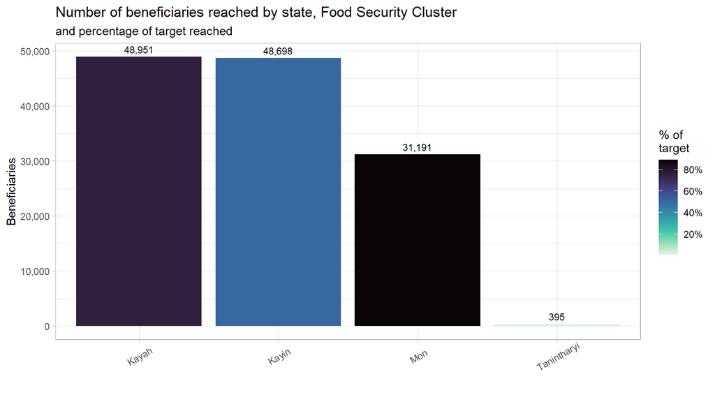

The table below outlines the number of beneficiaries reached by state/region in both 2021 and 2022/Q1. In 2021, the number of beneficiaries reached was lowest in Tanintharyi region, similarly more pronounced in 2022/Q1.

Skew in Q1 2022 geographic reach, comparison with 2021 data

| State | Beneficiaries_2021 | %_ben_2021 | Beneficiaries_2022 | %_ben_2022 | Target | %_target_2022 |
| --- | --- | --- | --- | --- | --- | --- |
| Kayah | 17,746 | 12.81 | 48,951 | 37.88 | 64,400 | 76.01 |
| Kayin | 68,108 | 49.17 | 48,698 | 37.68 | 96,320 | 50.56 |
| Mon | 48,181 | 34.78 | 31,191 | 24.14 | 35,000 | 89.12 |
| Tanintharyi | 4,476 | 3.23 | 395 | 0.31 | 54,410 | 0.73 |

### 1.2 Township-level breakdowns

Just 4 townships (listed in the table below) contained 63% of all beneficiaries. Reached 4 townships in Mon State which were not targeted in HRP 2022. Only few number of beneficiaries were reached in Loikaw and Ye townships which had a large number of target.

Townships reached by number of beneficiaries

| state | township | target | beneficiaries | %_beneficiaries | %_reached |
| --- | --- | --- | --- | --- | --- |
| Kayah | Hpruso | 4,000 | 30,215 | 23.38 | 755.4 |
| Kayin | Myawaddy | 5,000 | 20,843 | 16.13 | 416.9 |
| Kayah | Demoso | 25,000 | 16,315 | 12.62 | 65.26 |
| Kayin | Hpapun | 44,320 | 14,444 | 11.18 | 32.59 |
| Mon | Kyaikto | 10,000 | 8,284 | 6.41 | 82.84 |
| Kayin | Hlaingbwe | 15,000 | 7,778 | 6.02 | 51.85 |
| Mon | Chaungzon | 0 | 7,181 | 5.56 | 100 |
| Mon | Bilin | 5,000 | 6,031 | 4.67 | 120.6 |
| Mon | Paung | 0 | 4,254 | 3.29 | 100 |
| Kayin | Thandaunggyi | 7,000 | 2,811 | 2.18 | 40.16 |
| Mon | Mawlamyine | 0 | 2,691 | 2.08 | 100 |
| Mon | Kyaikmaraw | 0 | 2,570 | 1.99 | 100 |
| Kayah | Shadaw | 500 | 1,606 | 1.24 | 321.2 |
| Kayin | Kawkareik | 5,000 | 1,432 | 1.11 | 28.64 |
| Kayin | Kyainseikgyi | 5,000 | 1,390 | 1.08 | 27.8 |
| Kayah | Loikaw | 25,000 | 815 | 0.63 | 3.26 |
| Tanintharyi | Dawei | 5,667 | 314 | 0.24 | 5.54 |
| Mon | Ye | 10,000 | 180 | 0.14 | 1.8 |
| Tanintharyi | Yebyu | 4,751 | 81 | 0.06 | 1.7 |

### 1.3 Locations

A location refers to either an village, ward, IDP site or industrial zone.

This first plot below is a histogram of location, by number of beneficiaries. The vast majority of locations have only one activity occurring within them. This is something to be monitored over the course of the year, as it is assumed that a range of activities are required to comprehensively meet the food security and livelihoods needs of targeted communities. As it currently stands, the response is very broad, with little depth.

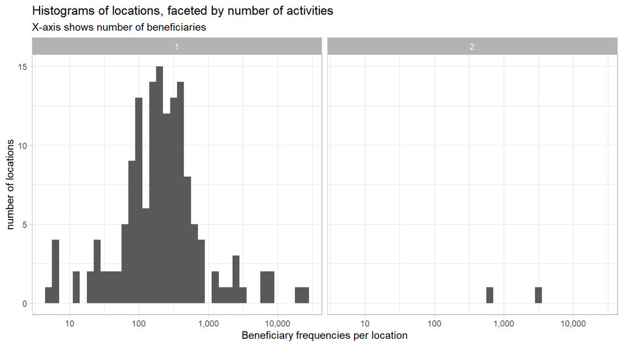

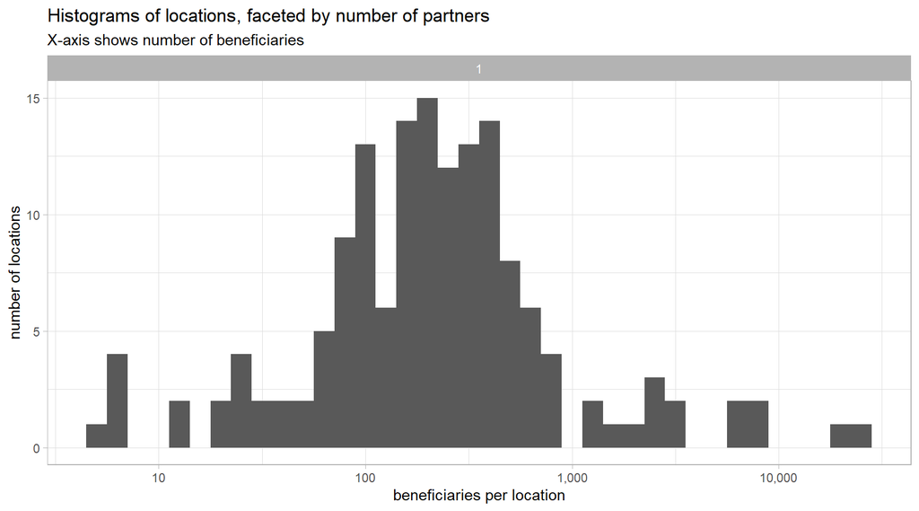

Breakdown of locations and beneficiaries

| rural_or_urban | location_type | locations | beneficiaries | %_of_ben | ben_per_location |
| --- | --- | --- | --- | --- | --- |
| Rural | Camp/IDP site | 52 | 28,603 | 22.24 | 550 |
| Rural | Village | 155 | 99,825 | 77.62 | 644 |
| Urban/Peri-Urban | Camp/IDP site | 1 | 104 | 0.08 | 104 |
| Urban/Peri-Urban | Village | 1 | 81 | 0.06 | 81 |

## 2. Activities

### 2.1 Progress by activity

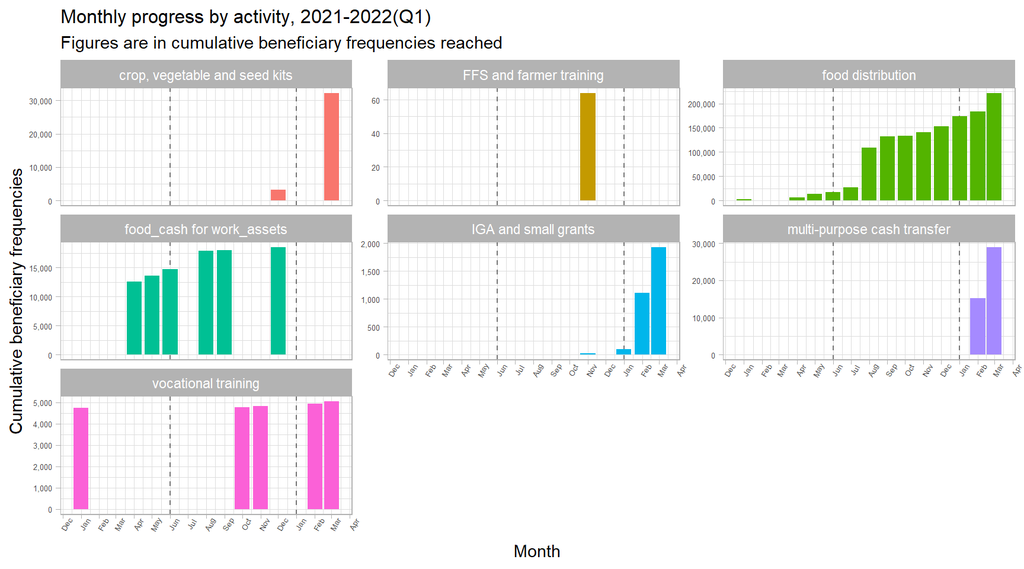

FFS and farmer training, and food cash for work/assets activities have not been implemented in 2022/Q1. Income-generating activities, which were very few in 2021, started to increase in 2022/Q1. Food distributions (in-kind and CBT/CVA) continued to be the largest activity from 2021 into 2022/Q1. Multi-purpose cash transfers was new activity that was not present in 2021.

### 2.2 Agricultural and livelihoods activities

Beneficiary frequencies reached by agricultural and non-agricultrural activities

| agricultural_activity | beneficiaries | %_beneficiaries | state | townships | partners |
| --- | --- | --- | --- | --- | --- |
| no | 98,309 | 76.07 | 4 | 13 | 3 |
| yes | 30,926 | 23.93 | 3 | 9 | 2 |

Crop, vegetable and seed kits formed the largest group of agricultural activities and reached 5,729 households (for a full breakdown by agricultural activity, please refer to the plot below).

It will be important to review the results from the second quarter in order to see if this pattern changes and agricultural household receive sufficient assistance prior to the main rice planting season which begins in May 2022. Still, the results are not encouraging and agricultural activities have had a very limited reach.

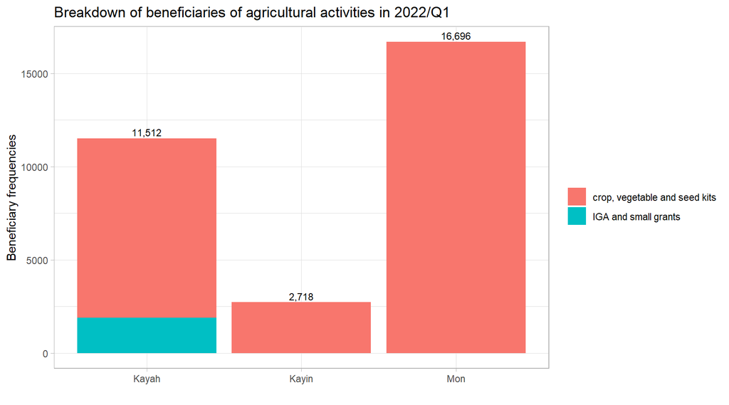

### 2.3 Delivery modalities

The plots below, faceted by delivery modality, show the breakdown of activities by delivery modality. All activities corresponded to only one type of delivery modality.

Percentage of beneficiaries reached by activity and delivery modality

[output not shown]

Both villages and IDP/Camp sites were predominated by in-kind distributions whilst only villages were targeted with cash-based interventions.

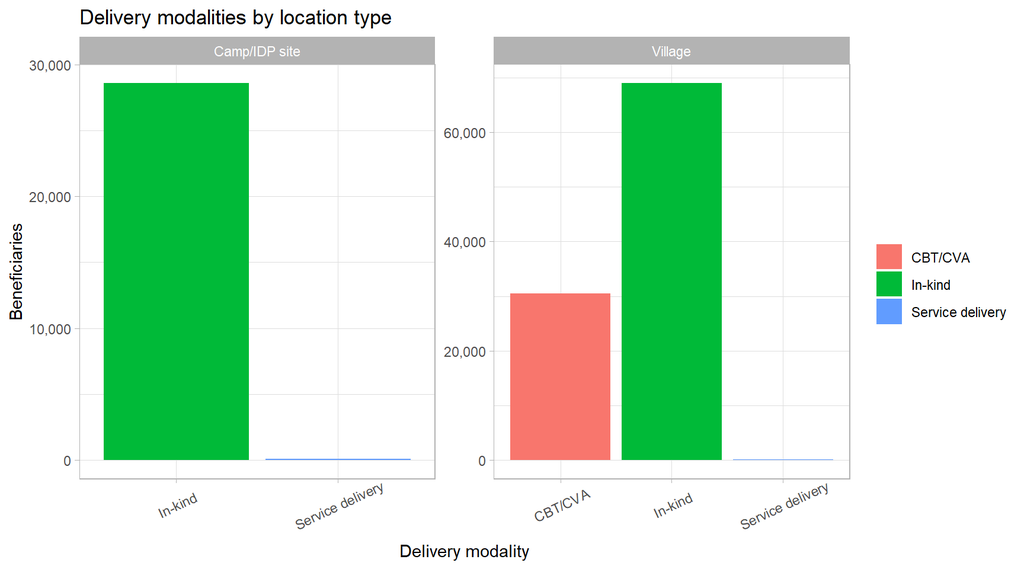

This would perhaps imply that partners believe that markets were more accessible from villages than camp/IDP sites. Other alternative assumptions include donor preferences and logistical challenges in bringing in-kind goods to villages. This remains a question to be explored by the broader Food Security Cluster.

Below is a breakdown of percentage of beneficiaries reached by the different delivery modalities, by state.

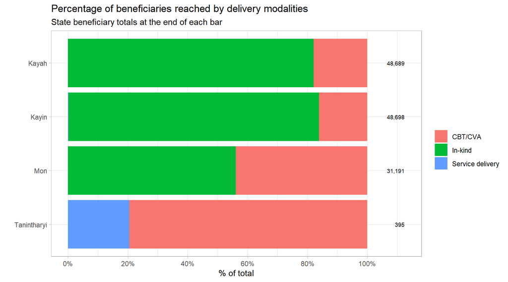

## 3. Cash-based programming

### 3.1 Cash transfer values per household

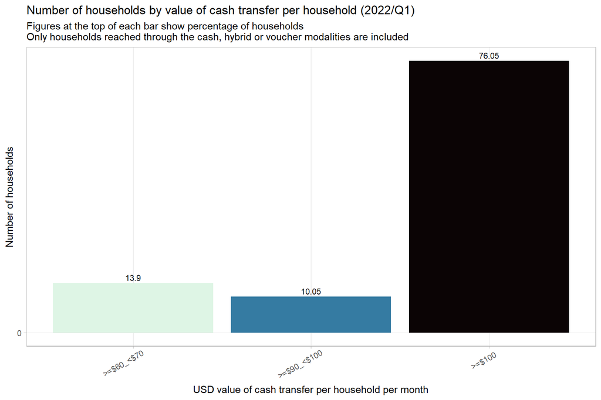

The table below shows the average USD values per transfer per household by and total transfer values per activity in the first quarter of 2022.

Only households which were reached by cash, hybrid or voucher modalities are included

| activity | hhd_frequencies | total_value_usd | avg_transfer_value |
| --- | --- | --- | --- |
| multi-purpose cash transfer | 5,110 | 454,046 | 88.85 |
| IGA and small grants | 303 | 20,473 | 67.57 |

### 3.2 Cash transfer values by implementing partner

The plots below show average cash transfer values by activity of the partners who reached the most beneficiaries.

The x-axis shows the average value per person or per household, depending on the activity and the colour indicates the number of beneficiaries reached.

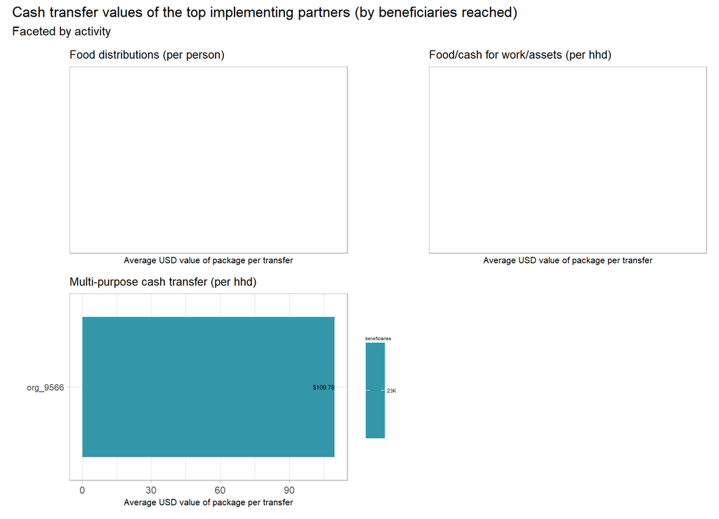

### 3.3 Cash transfer values per person

The boxplots above shows the range of cash transfer values (all values are per person, to facilitate comparability) by activity. The average for reach activity is marked by the thick line in the middle of each box. The leftmost and rightmost side of each box indicate the 25th and 75th percentile of transfer values, respectively. The length of each box is a gauge for how much variation there is in the transfer values of each activity.

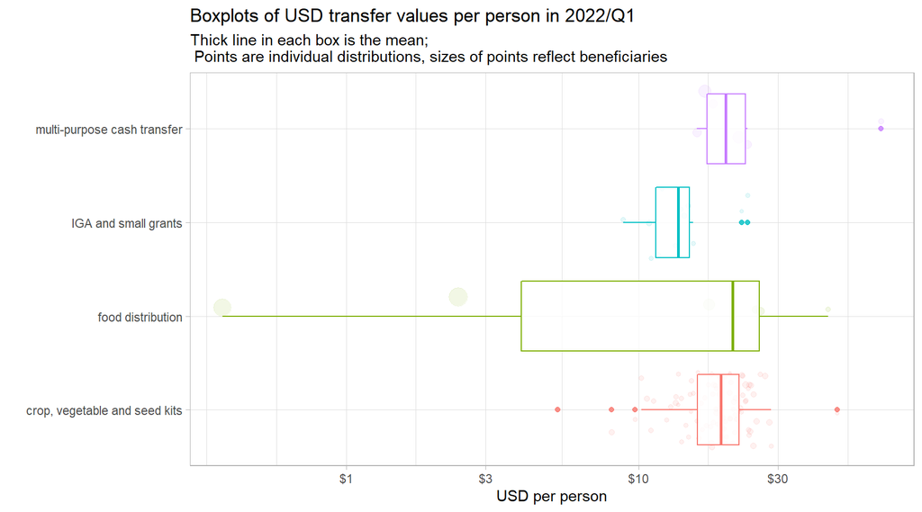

Additionally, each of the bubbles indicate an individual distribution, with their position along the x-axis showing the USD per person value of the distribution and the size of each bubble indicates the number of beneficiaries reached.

In the interactive scatterplot below, the x-axis indicates the number of beneficiaries reached and the y-axis indicates the per person value of each transfer. Each point is a distribution and the size of each point indicates the number of beneficiaries reached. More details about each distribution can be seen by hovering your cursor over each point.

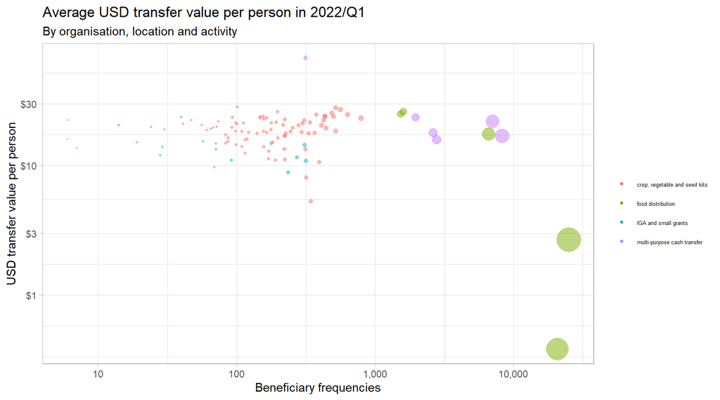

### 3.4 A closer look at food distributions

The interactive plot below breaks down the range of USD per person cash transfer values by state. Similar to the plot above, each point is a distribution and more details about each distribution can be seen by hovering your mouse over each point.

The red line indicates 50% of the monthly expenditure basket (MEB) for food (divided by 5 to get the figure per person). The vast majority of transfers fall below this value.

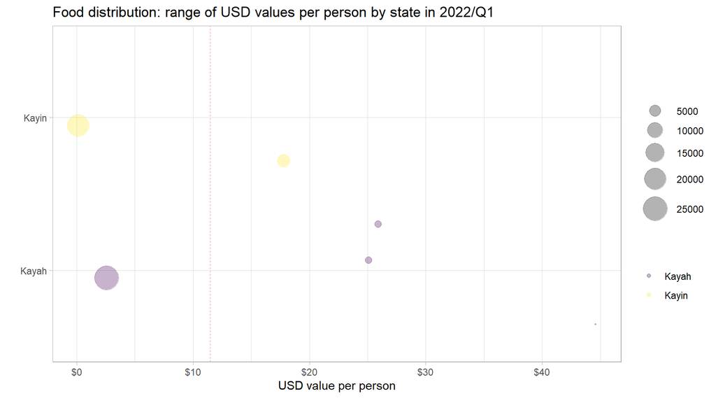

The table below compares the different bins for cash transfer values of food distributions with the minimum expenditure basket for food established by the Cash Working Group. They have established a floor of MMK 190,555 (or USD 114.55).

Monthly cash-based transfer values by percentage of MEB received

| usd_person_bin | avg_pc_of_meb | avg_usd_month | beneficiaries | pc_of_ben |
| --- | --- | --- | --- | --- |
| <$2 | 1.65 | 0.38 | 20,843 | 37.36 |
| >=$2_<$4 | 10.56 | 2.42 | 25,000 | 44.81 |
| >=$16_<$18 | 76.28 | 17.48 | 6,665 | 11.95 |
| >=$20 | 139.4 | 31.95 | 3,284 | 5.89 |

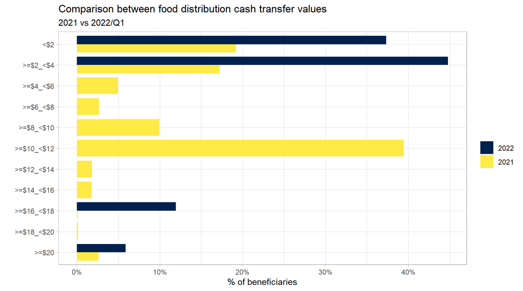

## 4. Beneficiaries

### 4.1 Beneficiary types

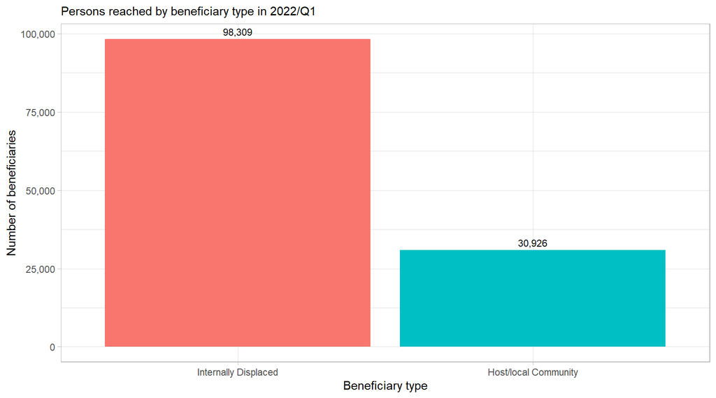

### 4.2 Evidence of food insecurity status

Food insecurity status and evidence provided in 2022/Q1

| food_insecurity_status | beneficiaries | %_benficiaries |
| --- | --- | --- |
| Moderately food insecure | 19,705 | 15.25 |
| Severely food insecure | 87,590 | 67.78 |
| No status provided | 21,940 | 16.98 |

Breakdown of evidence of food insecurity status in 2022/Q1

| evidence | beneficiaries | %_beneficiaries |
| --- | --- | --- |
| Armed conflict | 87,590 | 67.78 |
| No evidence | 41,645 | 32.22 |

The general lack of evidence of evidence of beneficiaries’ food insecurity status makes it difficult to justify to affected communities and donors that the Food Security Cluster is reaching the most in need. This highlights the need to promote a shared understanding of the response through the development of a common prioritisation tool for food security partners.

### 4.3 Beneficiary disaggregation

Due to the problems in reporting disaggregated beneficiary data, two tests have been applied to the submitted 5W data. The first involves a comparison to the proportions of disaggregation groups in the census to determine if values have been backfilled from the census.

The plots below show the breakdowns between the “real” values and those that have been backfilled from the census. Approximately 59% of beneficiaries reported had values that were not backfilled from the census; this is an improvement from 2021, where only 44% of beneficiaries had “real” disaggregations.

In the “real” values, it can be seen that the proportion of adult females reached is much higher than adult males – this is in line with the Cluster’s understanding of several activities that specifically target women. The percentages of elderly persons actually reached is also much lower than what has been reported.

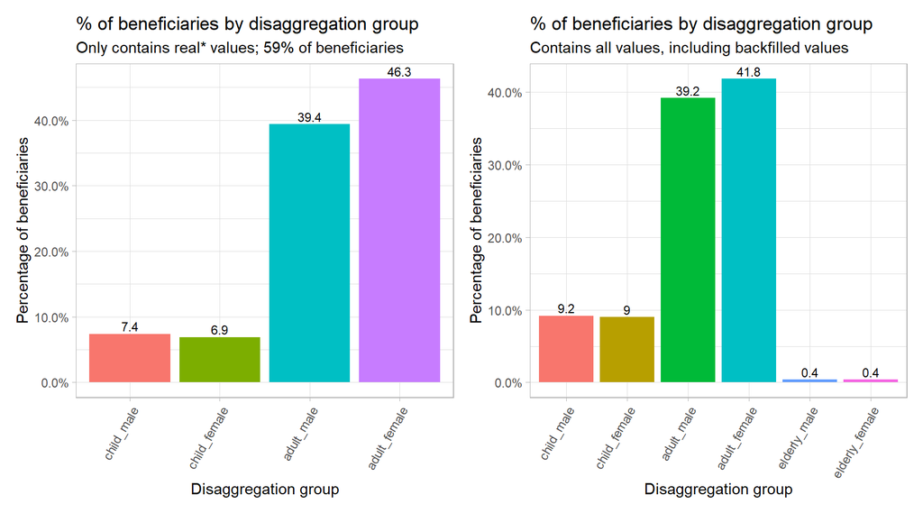

The second test applied is if the disaggregated numbers of beneficiaries reached have been copied and pasted. To do this, the proportions of each disaggregation group by partner have been compared to how close they were to the mean for the entire group. To explain: if partner A reported that 40% of beneficiaries in an activity were adult females, this percentage was then compared to the average percentage of adult females for all other activities reported by that partner. This measure whether or not the same proportions were copied and pasted throughout the 5W form.

It is extremely unlikely that these percentages would be similar across activities as implementing partners worked in an average of 32.39 locations.

In the plot below, the closer a value is to 0% on the x-axis, the more likely it is that it was copied and pasted. It is estimated that 89% of beneficiary disaggregation values were copied and pasted.

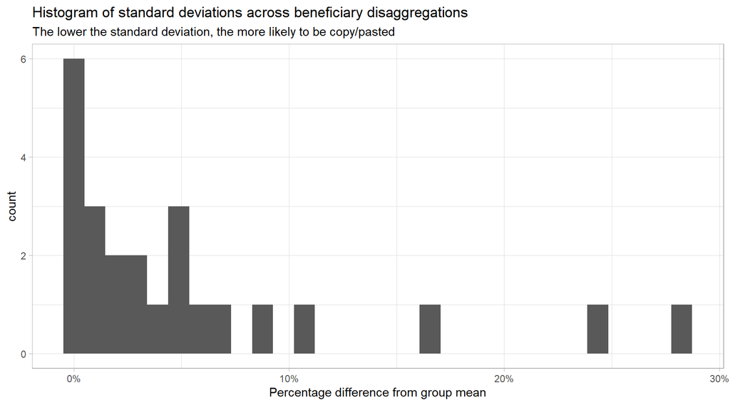

## 5. Partners

### 5.1 Reach by implementing partner

The interactive plot below shows the number of beneficiaries and townships reached by implementing partner.

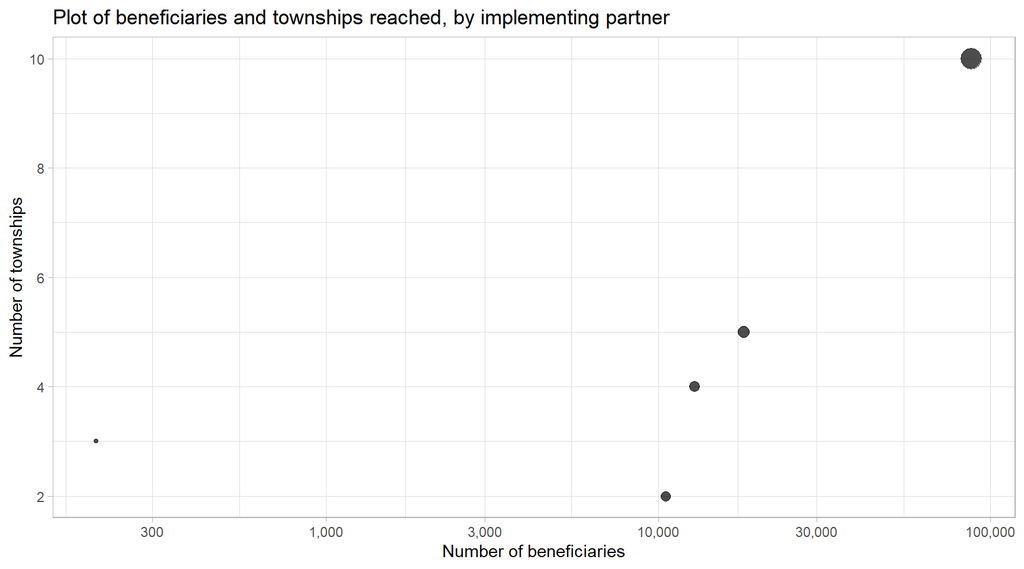

- Incentivise partners to expand their footprints
- Identify new partners to reach vulnerable persons in areas recently affected by conflict
- Encourage donors to support expansion of Food Security activities in areas recently affected by conflict (with sufficient support costs)

### 5.2 Monthly progress by partner

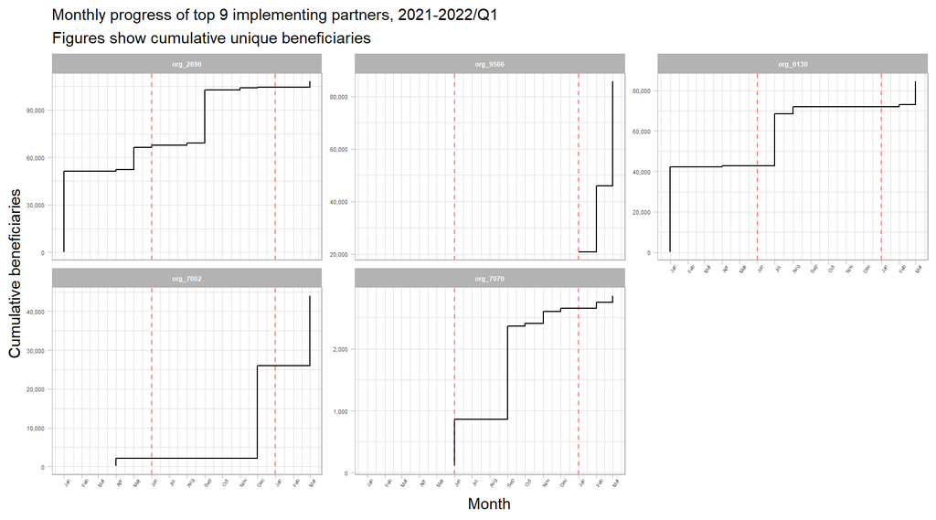

Top implementing partners by beneficiaries reached in 2022/Q1

| org_code | ben_2021 | rank_2021 | ben_2022 | rank_2022 | total_ben |
| --- | --- | --- | --- | --- | --- |
| org_9566 | NA | NA | 85,590 | 1 | 85,590 |
| org_7002 | 25,954 | 21 | 18,021 | 2 | 43,975 |
| org_6130 | 71,467 | 11 | 12,396 | 3 | 83,863 |
| org_2690 | 103,611 | 8 | 3,590 | 4 | 107,201 |
| org_7970 | 2,580 | 40 | 203 | 5 | 2,783 |
| org_1206 | 33,442 | 20 | NA | NA | 33,442 |
| org_1233 | 5,162 | 30 | NA | NA | 5,162 |
| org_1538 | 4,208 | 32 | NA | NA | 4,208 |
| org_2157 | 2,612 | 38 | NA | NA | 2,612 |
| org_2254 | 41,231 | 16 | NA | NA | 41,231 |
| org_2441 | 3,697 | 33 | NA | NA | 3,697 |
| org_2461 | 4,433 | 31 | NA | NA | 4,433 |
| org_2537 | 6,052 | 29 | NA | NA | 6,052 |
| org_2807 | 1,001 | 48 | NA | NA | 1,001 |
| org_2825 | 49,692 | 15 | NA | NA | 49,692 |

### 5.3 Donors

Top donors by benficiaries reached

| donor | beneficiaries | %_beneficiaries |
| --- | --- | --- |
| FCDO | 43,019 | 33.29 |
| CERF | 29,026 | 22.46 |
| WVI | 20,843 | 16.13 |
| BPRM | 13,457 | 10.41 |
| No donor specified | 10,516 | 8.14 |
| FCDO+BPRM | 7,059 | 5.46 |
| LIFT | 2,898 | 2.24 |
| Norad | 1,900 | 1.47 |
| Other donors | 517 | 0.4 |

## 6. Comparison with targets

### 6.2 Reached vs target by township

The specifics of each township can be reviewed with the interactive plot below. Each point is a township, with the size indicating the number of beneficiaries. The x-axis indicates the target population by township and the y-axis shows the number of beneficiaries reached in 2022/Q1.

The red line down the middle represents reaching 100% of the target. Townships above this line have reached more beneficiaries than their target and townships below the line have not met their target yet. The further away a township is from the red line, the further above or below its target it is. Mouse over each of the townships to see more details.

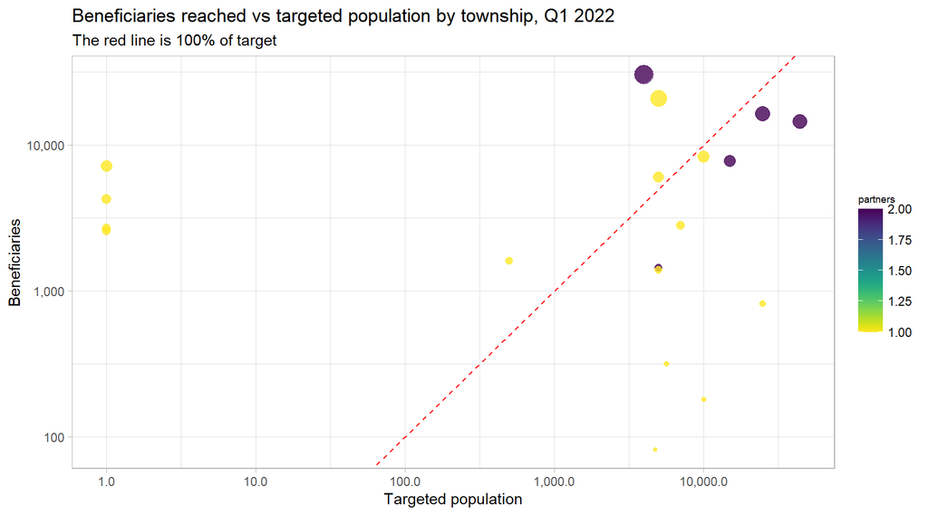

### 6.2 Map of beneficiaries reached in 2022/Q1 vs target

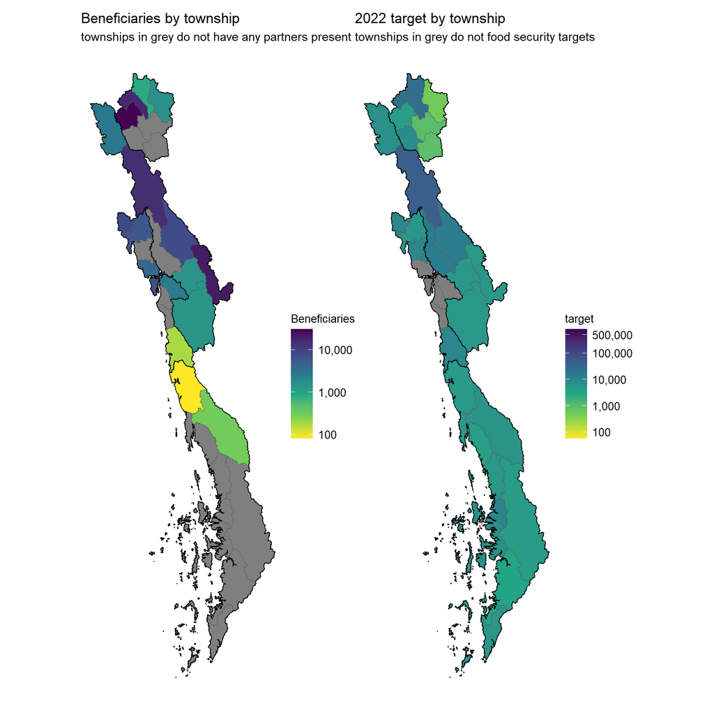

### 6.3 Interactive reference table

|  | state | township | target | beneficiaries | overreach | %_reached | partners |
| --- | --- | --- | --- | --- | --- | --- | --- |
| 1 | Kayah | Hpruso | 4000 | 30215 | 26215 | 755.38 | 2 |
| 2 | Kayin | Myawaddy | 5000 | 20843 | 15843 | 416.86 | 1 |
| 3 | Kayah | Demoso | 25000 | 16315 | -8685 | 65.26 | 2 |
| 4 | Kayin | Hpapun | 44320 | 14444 | -29876 | 32.59 | 2 |
| 5 | Mon | Kyaikto | 10000 | 8284 | -1716 | 82.84 | 1 |
| 6 | Kayin | Hlaingbwe | 15000 | 7778 | -7222 | 51.85 | 2 |
| 7 | Mon | Chaungzon | 0 | 7181 | 7181 | 100 | 1 |
| 8 | Mon | Bilin | 5000 | 6031 | 1031 | 120.62 | 1 |
| 9 | Mon | Paung | 0 | 4254 | 4254 | 100 | 1 |
| 10 | Kayin | Thandaunggyi | 7000 | 2811 | -4189 | 40.16 | 1 |

[output cut: 320 more lines]